```julia
ENV["PYTHON"] = ""
```

```
""
```

# Análisis del Catálogo de LASCO para CMEs

## Introducción

El propósito principal de este análisis es, además de el de ver qué fracción de los datos de CMEs son tipo "Halo", cuantos de estos eventos ocurren por año, y cuál es la distribución de velocidades de estos eventos.

El catálogo se puede encontrar en la liga https://cdaw.gsfc.nasa.gov/CME_list/ en la que se pueden ver todos los datos en detalle. Una descripción completa del catálogo puede encontrarse en la liga: https://cdaw.gsfc.nasa.gov/CME_list/catalog_description.htm por N. Gopalswamy, 2005 September 30, que contiene una lista de referencias, que se encuentran al final de esta libreta.

En las dos últimas columnas del catálogo se enuentran imágenes del medio interplanetario en presencia de las eyecciones, así como gráficas de datos del medio interplanetario de que provienen de otras fuentes, y una película java.

## Metodología

La versión de texto de los datos, que es la que vamos a utilizar se encuentra en la página: https://cdaw.gsfc.nasa.gov/CME_list/UNIVERSAL/text_ver/, la cual es necesario editar para quedarnos solamente con los datos. El archivo se llama univ_all.txt, el cual hay que bajar y poner en el directorio de la libreta.

```julia
A = readdlm("univ_all_NA.txt") # Lectura de los datos
```

```
26585x30 Array{Any,2}:
 "========="   "SOHO/LASCO"  …  ""  ""  ""  ""  ""  ""  ""  ""  ""
 "Date"        "Time"           ""  ""  ""  ""  ""  ""  ""  ""  ""
 "PA"          "Speed"          ""  ""  ""  ""  ""  ""  ""  ""  ""
 "1996/01/11"  "00:14:36"       ""  ""  ""  ""  ""  ""  ""  ""  ""
 "1996/01/13"  "22:08:30"       ""  ""  ""  ""  ""  ""  ""  ""  ""
 "1996/01/15"  "07:01:10"    …  ""  ""  ""  ""  ""  ""  ""  ""  ""
 "1996/01/22"  "03:11:01"       ""  ""  ""  ""  ""  ""  ""  ""  ""
 "1996/01/26"  "09:16:19"       ""  ""  ""  ""  ""  ""  ""  ""  ""
 "1996/01/31"  "06:52:13"       ""  ""  ""  ""  ""  ""  ""  ""  ""
 "1996/02/03"  "00:07:03"       ""  ""  ""  ""  ""  ""  ""  ""  ""
 "1996/02/08"  "05:17:49"    …  ""  ""  ""  ""  ""  ""  ""  ""  ""
 "1996/02/12"  "05:47:26"       ""  ""  ""  ""  ""  ""  ""  ""  ""
 "1996/02/17"  "02:06:31"       ""  ""  ""  ""  ""  ""  ""  ""  ""
 ⋮                           ⋱                  ⋮
 "2015/10/30"  "11:00:04"       ""  ""  ""  ""  ""  ""  ""  ""  ""
 "2015/10/30"  "15:14:23"       ""  ""  ""  ""  ""  ""  ""  ""  ""
 "2015/10/30"  "17:00:05"    …  ""  ""  ""  ""  ""  ""  ""  ""  ""
 "2015/10/30"  "19:00:04"       ""  ""  ""  ""  ""  ""  ""  ""  ""
 "2015/10/31"  "01:48:04"       ""  ""  ""  ""  ""  ""  ""  ""  ""
 "2015/10/31"  "03:36:04"       ""  ""  ""  ""  ""  ""  ""  ""  ""
 "2015/10/31"  "08:48:04"       ""  ""  ""  ""  ""  ""  ""  ""  ""
 "2015/10/31"  "09:12:09"    …  ""  ""  ""  ""  ""  ""  ""  ""  ""
 "2015/10/31"  "17:36:05"       ""  ""  ""  ""  ""  ""  ""  ""  ""
 "2015/10/31"  "18:36:04"       ""  ""  ""  ""  ""  ""  ""  ""  ""
 "2015/10/31"  "19:36:04"       ""  ""  ""  ""  ""  ""  ""  ""  ""
 "2015/10/31"  "23:12:09"       ""  ""  ""  ""  ""  ""  ""  ""  ""
```

Para quedarnos solamente con los datos propiamente dichos, es decir, sin encabezados ni comentarios, creamos la matriz B

```julia
B = [A[2,1:12]; A[4:end,1:12]]
```

```
26583x12 Array{Any,2}:
 "Date"        "Time"      …   "Mass"       "Kinetic"      "MPA"
 "1996/01/11"  "00:14:36"      "NA"         "NA"        272
 "1996/01/13"  "22:08:30"      "NA"         "NA"        266
 "1996/01/15"  "07:01:10"      "NA"         "NA"        272
 "1996/01/22"  "03:11:01"      "7.1e+13*"   "2.5e+28*"  103
 "1996/01/26"  "09:16:19"  …  3.0e14       1.0e29        90
 "1996/01/31"  "06:52:13"      "2.5e+14*"   "3.2e+28*"  272
 "1996/02/03"  "00:07:03"     1.9e15       8.9e29        80
 "1996/02/08"  "05:17:49"     1.6e14       2.7e28       249
 "1996/02/12"  "05:47:26"     1.3e15       1.6e29        92
 "1996/02/17"  "02:06:31"  …   "3.3e+14*"   "1.6e+29*"  274
 "1996/02/17"  "05:18:59"      "2.1e+14*"   "3.1e+28*"   88
 "1996/02/19"  "05:15:48"      "1.3e+14*"   "4.6e+28*"   94
 ⋮                         ⋱               ⋮
 "2015/10/30"  "11:00:04"      "NA"         "NA"        269
 "2015/10/30"  "15:14:23"     1.1e14       1.4e29       269
 "2015/10/30"  "17:00:05"      "2.0e+15*"   "3.6e+30*"  101
 "2015/10/30"  "19:00:04"      "NA"         "NA"        235
 "2015/10/31"  "01:48:04"  …  6.8e14       6.7e29       316
 "2015/10/31"  "03:36:04"     1.4e16       2.2e30       313
 "2015/10/31"  "08:48:04"      "NA"         "NA"         25
 "2015/10/31"  "09:12:09"      "NA"         "NA"        108
 "2015/10/31"  "17:36:05"      "NA"         "NA"         94
 "2015/10/31"  "18:36:04"  …   "NA"         "NA"         19
 "2015/10/31"  "19:36:04"     2.2e14       3.5e28       138
 "2015/10/31"  "23:12:09"      "NA"         "NA"         81
```

Creamos y salvamos, a partir de este arreglo, el data frame df_cme, para lo cual tenemos que entrar al sistema de dataFrame

```julia
writedlm("lasco_petit.txt", B)
```

```julia
using DataFrames, DataArrays
df = readtable("lasco_petit.txt", separator = '\t')
```

|  | Date | Time | Central | Width | Linear | x2nd | order | speed | Accel | Mass | Kinetic | MPA |
| --- | --- | --- | --- | --- | --- | --- | --- | --- | --- | --- | --- | --- |
| 1 | 1996/01/11 | 00:14:36 | 267 | 18 | 499 | 571 | 426 | 0 | -64.3* | NA | NA | 272 |
| 2 | 1996/01/13 | 22:08:30 | 265 | 16 | 290 | 278 | 303 | 372 | 2.8* | NA | NA | 266 |
| 3 | 1996/01/15 | 07:01:10 | 262 | 43 | 525 | 600 | 454 | 0 | -31.1 | NA | NA | 272 |
| 4 | 1996/01/22 | 03:11:01 | 105 | 37 | 267 | 401 | 130 | 0 | -126.3* | 7.1e+13* | 2.5e+28* | 103 |
| 5 | 1996/01/26 | 09:16:19 | 90 | 27 | 262 | 254 | 271 | 322 | 1.9* | 3e14 | 1e29 | 90 |
| 6 | 1996/01/31 | 06:52:13 | 274 | 47 | 158 | 219 | 99 | 0 | -12.3* | 2.5e+14* | 3.2e+28* | 272 |
| 7 | 1996/02/03 | 00:07:03 | 83 | 52 | 306 | 294 | 317 | 309 | 0.9* | 19e14 | 89e28 | 80 |
| 8 | 1996/02/08 | 05:17:49 | 263 | 70 | 184 | 247 | 126 | 0 | -6.0* | 16e13 | 27e27 | 249 |
| 9 | 1996/02/12 | 05:47:26 | 91 | 53 | 160 | 100 | 211 | 236 | 2.0* | 13e14 | 16e28 | 92 |
| 10 | 1996/02/17 | 02:06:31 | 279 | 73 | 317 | 257 | 378 | 532 | 9.9* | 3.3e+14* | 1.6e+29* | 274 |
| 11 | 1996/02/17 | 05:18:59 | 86 | 36 | 171 | 64 | 279 | 819 | 27.9* | 2.1e+14* | 3.1e+28* | 88 |
| 12 | 1996/02/19 | 05:15:48 | 98 | 30 | 266 | 129 | 403 | 946 | 36.7* | 1.3e+14* | 4.6e+28* | 94 |
| 13 | 1996/03/02 | 04:11:53 | 88 | 36 | 108 | 95 | 120 | 177 | 1.0* | 15e13 | 87e26 | 86 |
| 14 | 1996/03/03 | 04:12:30 | 99 | 26 | 186 | 141 | 232 | 215 | 2.3* | 1.6e+14* | 2.8e+28* | 99 |
| 15 | 1996/03/06 | 05:38:36 | 268 | 55 | 175 | NA | NA | NA | NA | 3.6e+13* | 5.6e+27* | 261 |
| 16 | 1996/03/07 | 01:00:19 | 57 | 39 | 200 | 235 | 169 | 135 | -2.3* | 3.8e+14* | 7.5e+28* | 53 |
| 17 | 1996/03/07 | 07:51:56 | 91 | 43 | 60 | 60 | 61 | 75 | 0.1* | NA | NA | 87 |
| 18 | 1996/03/08 | 07:12:03 | 90 | 19 | 170 | 108 | 229 | 189 | 2.8* | NA | NA | 85 |
| 19 | 1996/03/09 | 04:27:49 | 84 | 39 | 93 | 102 | 82 | 0 | -1.1* | NA | NA | 82 |
| 20 | 1996/03/11 | 18:22:39 | 86 | 52 | 244 | 124 | 352 | 656 | 20.1* | 4.4e+14* | 1.3e+29* | 77 |
| 21 | 1996/03/13 | 02:42:06 | 105 | 17 | 130 | 68 | 195 | 312 | 4.0* | NA | NA | 106 |
| 22 | 1996/03/14 | 09:38:00 | 101 | 22 | 74 | 55 | 94 | 177 | 1.2* | NA | NA | 99 |
| 23 | 1996/03/14 | 11:44:18 | 285 | 59 | 418 | 526 | 307 | 302 | -8.9* | 1.2e+15* | 1.0e+30* | 292 |
| 24 | 1996/03/15 | 13:54:27 | 101 | 26 | 222 | 200 | 244 | 386 | 4.7* | NA | NA | 101 |
| 25 | 1996/03/15 | 23:57:34 | 76 | 29 | 71 | 46 | 98 | 198 | 1.9* | NA | NA | 78 |
| 26 | 1996/03/16 | 02:03:38 | 262 | 27 | 65 | 26 | 107 | 292 | 3.8* | NA | NA | 267 |
| 27 | 1996/03/18 | 02:45:52 | 94 | 22 | NA | NA | NA | NA | NA | NA | NA | 92 |
| 28 | 1996/03/18 | 08:33:09 | 276 | 25 | 158 | 137 | 177 | 212 | 1.2* | 1.3e+14* | 1.7e+28* | 280 |
| 29 | 1996/03/18 | 16:26:43 | 257 | 32 | NA | NA | NA | NA | NA | NA | NA | 263 |
| 30 | 1996/03/22 | 00:48:44 | 282 | 17 | 142 | 107 | 177 | 228 | 2.0* | NA | NA | 284 |
| ⋮ | ⋮ | ⋮ | ⋮ | ⋮ | ⋮ | ⋮ | ⋮ | ⋮ | ⋮ | ⋮ | ⋮ | ⋮ |

## Rapidez de los CMEs a lo largo del período 1996 - 2015

Debido a que en el catálogo existen valores "NA", se usa el comando dropna() para eliminarlos.

```
[Plots.jl] Initializing backend: pyplot
```

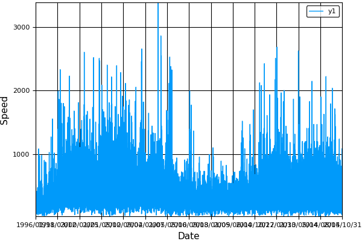

```julia
using Plots
pyplot()
#plot(dropna(df[5]))
plot(df[1], dropna(df[5]), xlabel = "Date", ylabel = "Speed", fmt = :png)
```

## Número de CMEs por año

```julia
df[207,1]
```

```
"1997/01/02"
```

```julia
# ultimo indice del año
indiceY = [1995 0; 1996 206; 1997 591; 1998 1307; 1999 2323; 2000 3987; 2001 5486; 2002 7186; 2003 8316; 2004 9418; 2005 10667; 2006 11713;
2007 13155; 2008 14018; 2009 14764; 2010 15881; 2011 17860; 2012 20038; 2013 22376; 2014 24854; 2015 26582]
```

```
21x2 Array{Int64,2}:
 1995      0
 1996    206
 1997    591
 1998   1307
 1999   2323
 2000   3987
 2001   5486
 2002   7186
 2003   8316
 2004   9418
 2005  10667
 2006  11713
 2007  13155
 2008  14018
 2009  14764
 2010  15881
 2011  17860
 2012  20038
 2013  22376
 2014  24854
 2015  26582
```

```julia
numero = indiceY[2:end,2] - indiceY[1:end-1,2]
```

```
20-element Array{Int64,1}:
  206
  385
  716
 1016
 1664
 1499
 1700
 1130
 1102
 1249
 1046
 1442
  863
  746
 1117
 1979
 2178
 2338
 2478
 1728
```

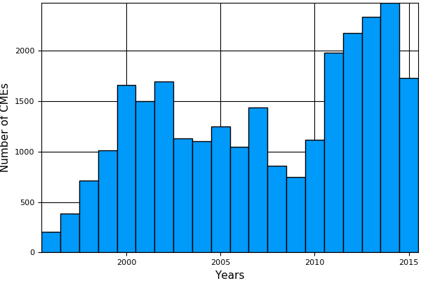

```julia
plot(indiceY[2:end,1], numero, t = :bar, xlabel="Years", ylabel = "Number of CMEs", leg = false)
```

Veamos ahora el comportamiento del ciclo solar para estos años, para lo cual utilizaremos el número de manchas solares (fuente: "Source: WDC-SILSO, Royal Observatory of Belgium, Brussels").

```julia
manchas = readdlm("SN_y_tot_V2.0.txt")
```

```
317x5 Array{Any,2}:
 1700.5    8.3  -1.0    -1  ""
 1701.5   18.3  -1.0    -1  ""
 1702.5   26.7  -1.0    -1  ""
 1703.5   38.3  -1.0    -1  ""
 1704.5   60.0  -1.0    -1  ""
 1705.5   96.7  -1.0    -1  ""
 1706.5   48.3  -1.0    -1  ""
 1707.5   33.3  -1.0    -1  ""
 1708.5   16.7  -1.0    -1  ""
 1709.5   13.3  -1.0    -1  ""
 1710.5    5.0  -1.0    -1  ""
 1711.5    0.0  -1.0    -1  ""
 1712.5    0.0  -1.0    -1  ""
    ⋮
 2005.5   45.8   4.7  7084  ""
 2006.5   24.7   3.5  6370  ""
 2007.5   12.6   2.7  6841  ""
 2008.5    4.2   2.5  6644  ""
 2009.5    4.8   2.5  6465  ""
 2010.5   24.9   3.4  6328  ""
 2011.5   80.8   6.7  6077  ""
 2012.5   84.5   6.7  5753  ""
 2013.5   94.0   6.9  5347  ""
 2014.5  113.3   8.0  5273  ""
 2015.5   69.8   6.4  8903  ""
 2016.5   39.9   3.9  9724  "*"
```

```julia
n0 = manchas[end-20:end-1,1:2]
```

```
20x2 Array{Any,2}:
 1996.5   11.6
 1997.5   28.9
 1998.5   88.3
 1999.5  136.3
 2000.5  173.9
 2001.5  170.4
 2002.5  163.6
 2003.5   99.3
 2004.5   65.3
 2005.5   45.8
 2006.5   24.7
 2007.5   12.6
 2008.5    4.2
 2009.5    4.8
 2010.5   24.9
 2011.5   80.8
 2012.5   84.5
 2013.5   94.0
 2014.5  113.3
 2015.5   69.8
```

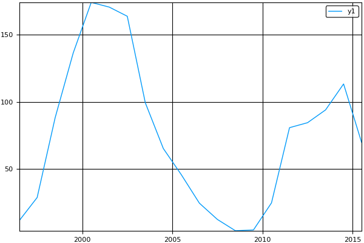

```julia
plot(n0[:,1],n0[:,2])
```

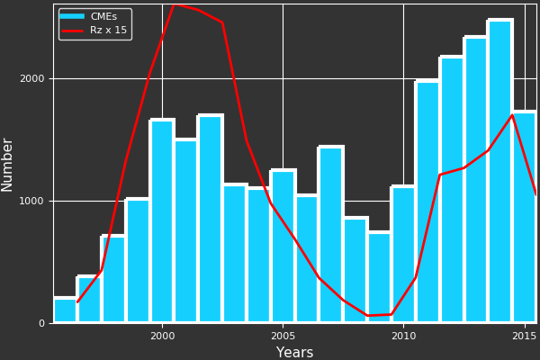

```julia
pyplot()
bar(indiceY[2:end,1], numero, xlabel="Years", ylabel = "Number",
lab="CMEs",w=3, background_color=RGB(0.2,0.2,0.2))
plot!(n0[:,1],15*n0[:,2], lab = "Rz x 15", line = :red, linewidth = 2, fmt = :png)
```

## Distribución de rapideces de las CMEs

Se puede obtener fácilmente mediante el cálculo del histograma

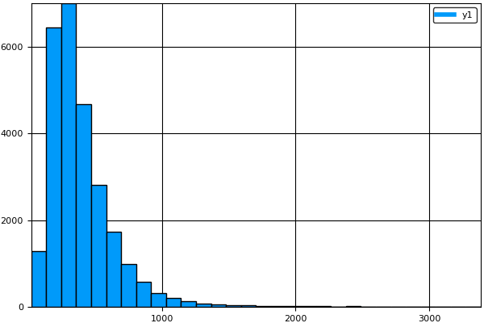

```julia
h = histogram(dropna(df[5]))
```

```julia
v = hist(dropna(df[5]), 24)
```

```
(0.0:200.0:3400.0,[4721,12148,5724,2338,858,339,147,73,45,34,20,10,11,4,1,0,1])
```

```julia
# Programa para buscar valores por encima de ciertas rapideces
rapidez = dropna(df[5])
num0200 = length(rapidez[find(rapidez .> 200)])
num0400 = length(rapidez[find(rapidez .> 400)])
num0600 = length(rapidez[find(rapidez .> 600)])
num0800 = length(rapidez[find(rapidez .> 800)])
num1000 = length(rapidez[find(rapidez .> 1000)])
num1200 = length(rapidez[find(rapidez .> 1200)])
num1400 = length(rapidez[find(rapidez .> 1400)])
num1600 = length(rapidez[find(rapidez .> 1600)])
num1800 = length(rapidez[find(rapidez .> 1800)])
num2000 = length(rapidez[find(rapidez .> 2000)])
num2200 = length(rapidez[find(rapidez .> 2200)])
total = [num0200; num0400; num0600; num0800; num1000; num1200; num1400; num1600;
    num1800; num2000; num2200]
```

```
11-element Array{Int64,1}:
 21753
  9605
  3881
  1543
   685
   346
   199
   126
    81
    47
    27
```

```julia
# Programa para buscar valores por arriva de diferentes rapideces
speed = dropna(df[5])
nk2200 = 0; nk2000 = 0; nk1800 = 0; nk1600 = 0; nk1400 = 0; nk1200 = 0; nk1000 = 0;
nk0800 = 0; nk0600 = 0; nk0400 = 0; nk0200 = 0
for i = 1:26474
    if speed[i] > 200
        nk0200 += 1
    end
    if speed[i] > 400
        nk0400 += 1
    end
    if speed[i] > 600
        nk0600 += 1
    end
    if speed[i] > 800
        nk0800 += 1
    end
    if speed[i] > 1000
        nk1000 += 1
    end
    if speed[i] > 1200
        nk1200 += 1
    end
    if speed[i] > 1400
        nk1400 += 1
    end
    if speed[i] > 1600
        nk1600 += 1
    end
    if speed[i] > 1800
        nk1800 += 1
    end
    if speed[i] > 2000
        nk2000 += 1
    end
    if speed[i] > 2200
        nk2200 += 1
    end
end
nk = [nk0200 nk0400 nk0600 nk0800 nk1000 nk1200 nk1400 nk1600 nk1800 nk2000 nk2200]
```

```
1x11 Array{Int64,2}:
 21753  9605  3881  1543  685  346  199  126  81  47  27
```

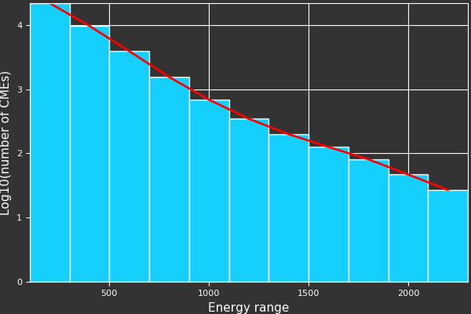

```julia
range = collect(200:200:2200)
bar(range, log10(total),
xlabel="Energy range", ylabel="Log10(number of CMEs)",
background_color=RGB(0.2,0.2,0.2))
plot!(range, log10(nk)', line = :red, linewidth = 2, leg = false)
```

# Los CMEs con categoría de Halo

Debido a sus características de "verse" a ambos lados del sol, estas CMEs tienen rumbo hacia la Tierra, por lo que son de mayor interés para el clima espacial. Como sólo estamos interesados en los CMEs tipo Halo, es necesario hacer un nuevo archivo que contenga tales eventos.

```julia
df1 = df[(df[:Central] .== "Halo"), :]
```

|  | Date | Time | Central | Width | Linear | x2nd | order | speed | Accel | Mass | Kinetic | MPA |
| --- | --- | --- | --- | --- | --- | --- | --- | --- | --- | --- | --- | --- |
| 1 | 1996/04/29 | 14:38:48 | Halo | 360 | 65 | NA | NA | NA | NA | NA | NA | 149 |
| 2 | 1996/08/16 | 14:14:06 | Halo | 360 | 364 | 336 | 390 | 399 | 2.0* | 5.6e+14* | 3.7e+29* | 158 |
| 3 | 1996/11/07 | 23:20:05 | Halo | 360 | 497 | 366 | 630 | 586 | 8.7 | 4.2e+15* | 5.2e+30* | 114 |
| 4 | 1996/12/02 | 15:35:05 | Halo | 360 | 538 | 641 | 430 | 478 | -8.8 | 1.6e+15* | 2.3e+30* | 253 |
| 5 | 1997/01/06 | 15:10:42 | Halo | 360 | 136 | 51 | 224 | 319 | 4.1 | 5.8e+14* | 5.4e+28* | 180 |
| 6 | 1997/02/07 | 00:30:05 | Halo | 360 | 490 | 270 | 718 | 635 | 14.3 | 4.1e+15* | 4.9e+30* | 266 |
| 7 | 1997/04/07 | 14:27:44 | Halo | 360 | 878 | 850 | 905 | 896 | 3.3 | 1.0e+16* | 4.0e+31* | 123 |
| 8 | 1997/04/27 | 10:26:05 | Halo | 360 | 280 | 288 | 271 | 268 | -.5 | 4.5e+14* | 1.7e+29* | 268 |
| 9 | 1997/04/27 | 14:59:05 | Halo | 360 | 255 | 324 | 180 | 0 | -4.9 | 2.5e+14* | 8.1e+28* | 270 |
| 10 | 1997/05/12 | 05:30:05 | Halo | 360 | 464 | 580 | 335 | 220 | -15.0* | 4.2e+15* | 4.5e+30* | 264 |
| 11 | 1997/07/30 | 04:45:47 | Halo | 360 | 104 | 90 | 119 | 162 | .8 | 8.2e+14* | 4.5e+28* | 269 |
| 12 | 1997/08/30 | 01:30:35 | Halo | 360 | 371 | 291 | 460 | 551 | 9.3 | 1.7e+15* | 1.2e+30* | 67 |
| 13 | 1997/09/17 | 20:28:48 | Halo | 360 | 377 | 377 | 377 | 377 | 0 | 2.6e+15* | 1.9e+30* | 263 |
| 14 | 1997/09/28 | 01:08:33 | Halo | 360 | 359 | 317 | 404 | 409 | 2.8 | 4.0e+15* | 2.6e+30* | 87 |
| 15 | 1997/10/21 | 18:03:45 | Halo | 360 | 523 | 552 | 491 | 484 | -2.9 | 9.5e+14* | 1.3e+30* | 90 |
| 16 | 1997/10/23 | 11:26:50 | Halo | 360 | 503 | 443 | 573 | 526 | 3.7 | 8.2e+15* | 1.0e+31* | 305 |
| 17 | 1997/11/04 | 06:10:05 | Halo | 360 | 785 | 1009 | 548 | 698 | -22.1 | 7.5e+15* | 2.3e+31* | 243 |
| 18 | 1997/11/06 | 12:10:41 | Halo | 360 | 1556 | 1755 | 1346 | 1473 | -44.1 | 5.5e+15* | 6.6e+31* | 262 |
| 19 | 1997/11/17 | 08:27:05 | Halo | 360 | 611 | 743 | 470 | 532 | -14.5 | 8.2e+15* | 1.5e+31* | 164 |
| 20 | 1997/11/19 | 12:27:08 | Halo | 360 | 150 | 166 | 133 | 0 | -5.1* | 8.1e+14* | 9.1e+28* | 280 |
| 21 | 1997/12/18 | 23:47:31 | Halo | 360 | 417 | 363 | 472 | 436 | 2.9 | 8.3e+15* | 7.2e+30* | 102 |
| 22 | 1998/01/02 | 23:28:20 | Halo | 360 | 438 | 337 | 548 | 515 | 6.5 | 5.5e+15* | 5.3e+30* | 275 |
| 23 | 1998/01/17 | 04:09:20 | Halo | 360 | 350 | 242 | 471 | 429 | 5.6 | 1.6e+15* | 9.7e+29* | 82 |
| 24 | 1998/01/21 | 06:37:25 | Halo | 360 | 361 | 335 | 389 | 384 | 1.5* | 2.6e+15* | 1.7e+30* | 179 |
| 25 | 1998/01/25 | 15:26:34 | Halo | 360 | 693 | 773 | 611 | 657 | -7.4 | 1.1e+16* | 2.7e+31* | 112 |
| 26 | 1998/02/27 | 20:07:21 | Halo | 360 | 422 | 506 | 340 | 0 | -10.8* | NA | NA | 83 |
| 27 | 1998/03/29 | 03:48:28 | Halo | 360 | 1397 | 1416 | 1378 | 1389 | -4.9* | 1.7e+16* | 1.7e+32* | 189 |
| 28 | 1998/03/31 | 06:12:02 | Halo | 360 | 1992 | NA | NA | NA | NA | 1.6e+16* | 3.1e+32* | 177 |
| 29 | 1998/04/23 | 05:55:22 | Halo | 360 | 1691 | 1919 | 1466 | 1649 | -44.4* | 5.5e+15* | 7.9e+31* | 116 |
| 30 | 1998/04/27 | 08:56:06 | Halo | 360 | 1385 | 1035 | 1743 | 1696 | 74.4 | 2.2e+16* | 2.1e+32* | 79 |
| ⋮ | ⋮ | ⋮ | ⋮ | ⋮ | ⋮ | ⋮ | ⋮ | ⋮ | ⋮ | ⋮ | ⋮ | ⋮ |

```julia
length(df1[:Date])
```

```
693
```

## Rapidez de CMEs tipo Halo a lo largo del periodo

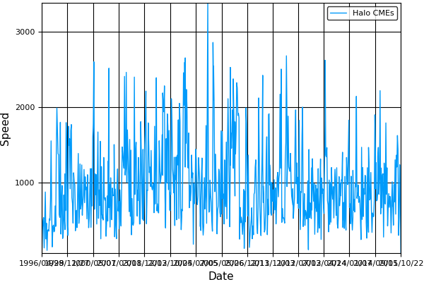

```julia
plot(df1[1], dropna(df1[5]),
xlabel = "Date", ylabel = "Speed", lab = "Halo CMEs", fmt = :png)
```

## Número de CMEs tipo Halo a lo largo del periodo

```julia
df1[410,1]
```

```
"2011/02/01"
```

```julia
# Ultimo índice del año
indiceY1 = [1995 0; 1996 4; 1997 21; 1998 50; 1999 77; 2000 135; 2001 198;
    2002 250; 2003 280; 2004 320; 2005 379; 2006 393; 2007 396; 2008 397;
    2009 398; 2010 409; 2011 450; 2012 534; 2013 589; 2014 658; 2015 693]
```

```
21x2 Array{Int64,2}:
 1995    0
 1996    4
 1997   21
 1998   50
 1999   77
 2000  135
 2001  198
 2002  250
 2003  280
 2004  320
 2005  379
 2006  393
 2007  396
 2008  397
 2009  398
 2010  409
 2011  450
 2012  534
 2013  589
 2014  658
 2015  693
```

```julia
numero1 = indiceY1[2:end,2] - indiceY1[1:end-1,2]
```

```
20-element Array{Int64,1}:
  4
 17
 29
 27
 58
 63
 52
 30
 40
 59
 14
  3
  1
  1
 11
 41
 84
 55
 69
 35
```

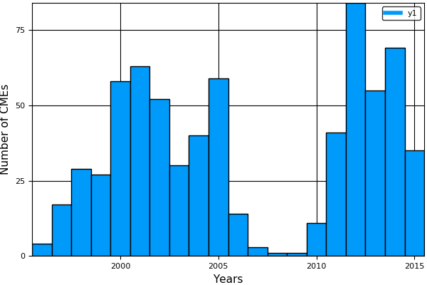

```julia
bar(indiceY1[2:end,1], numero1, xlabel="Years", ylabel = "Number of CMEs", fmt = :png)
```

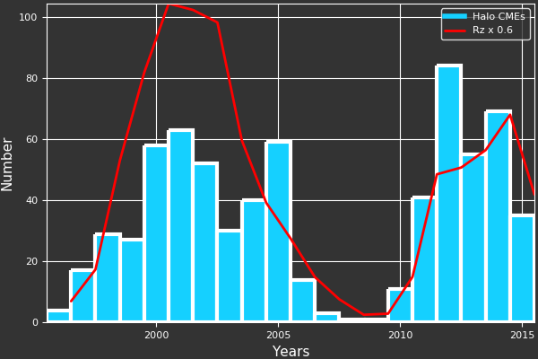

```julia
pyplot()
bar(indiceY1[2:end,1], numero1, xlabel="Years", ylabel = "Number",
lab="Halo CMEs",w=3, background_color=RGB(0.2,0.2,0.2))
plot!(n0[:,1],0.6*n0[:,2], lab = "Rz x 0.6", line = :red, linewidth = 2, fmt = :png)
```

## Distribución de rapideces de las Halo CMEs

Se puede obtener fácilmente mediante el cálculo del histograma

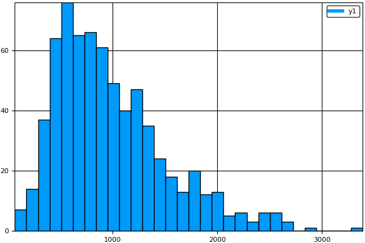

```julia
h1 = histogram(dropna(df1[5]))
```

```julia
# Programa para buscar valores por arriva de diferentes rapideces
speed1 = dropna(df1[5])
nk2200a = 0; nk2000a = 0; nk1800a = 0; nk1600a = 0; nk1400a = 0;
nk1200a = 0; nk1000a = 0; nk0800a = 0; nk0600a = 0; nk0400a = 0;
nk0200a = 0
for i = 1:692
    if speed1[i] > 200
        nk0200a += 1
    end
    if speed1[i] > 400
        nk0400a += 1
    end
    if speed1[i] > 600
        nk0600a += 1
    end
    if speed1[i] > 800
        nk0800a += 1
    end
    if speed1[i] > 1000
        nk1000a += 1
    end
    if speed1[i] > 1200
        nk1200a += 1
    end
    if speed1[i] > 1400
        nk1400a += 1
    end
    if speed1[i] > 1600
        nk1600a += 1
    end
    if speed1[i] > 1800
        nk1800a += 1
    end
    if speed1[i] > 2000
        nk2000a += 1
    end
    if speed1[i] > 2200
        nk2200a += 1
    end
end
#nk1 = [nk0200a nk0400a nk0600a nk0800a nk1000a nk1200a nk1400a nk1600a
#    nk1800a nk2000a nk2200a]
```

```julia
nk1 = [nk0200a; nk0400a; nk0600a; nk0800a; nk1000a; nk1200a; nk1400a;
    nk1600a; nk1800a; nk2000a; nk2200a]
```

```
11-element Array{Int64,1}:
 684
 632
 506
 387
 274
 193
 130
  90
  64
  39
  24
```

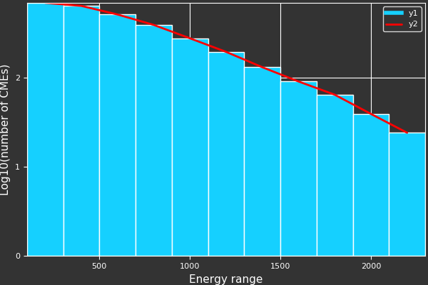

```julia
range = collect(200:200:2200)
bar(range, log10(nk1),
xlabel="Energy range", ylabel="Log10(number of CMEs)",
background_color=RGB(0.2,0.2,0.2))
plot!(range, log10(nk1), line = :red, linewidth = 2, fmt = :png)
```

```julia
dfes = [numero numero1 100*(numero1./numero)]
```

```
20x3 Array{Float64,2}:
  206.0   4.0  1.94175
  385.0  17.0  4.41558
  716.0  29.0  4.05028
 1016.0  27.0  2.65748
 1664.0  58.0  3.48558
 1499.0  63.0  4.2028
 1700.0  52.0  3.05882
 1130.0  30.0  2.65487
 1102.0  40.0  3.62976
 1249.0  59.0  4.72378
 1046.0  14.0  1.33843
 1442.0   3.0  0.208044
  863.0   1.0  0.115875
  746.0   1.0  0.134048
 1117.0  11.0  0.984781
 1979.0  41.0  2.07175
 2178.0  84.0  3.85675
 2338.0  55.0  2.35244
 2478.0  69.0  2.7845
 1728.0  35.0  2.02546
```

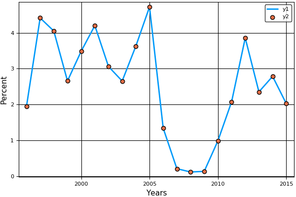

```julia
plot(indiceY[2:end,1], dfes[:,3], w=2, xlabel="Years", ylabel="Percent")
scatter!(indiceY[2:end,1], dfes[:,3])
```

## Referencias

S. Yashiro, G. Michalek, and N. Gopalswamy, A comparison of coronal mass ejections identified by manual and automatic methods, accepted for the publication in Annales Geophysicae

N. Gopalswamy, S. Yashiro, G. Michalek, G. Stenborg, A. Vourlidas, S. Freeland, and R. Howard, The SOHO/LASCO CME Catalog, accepted for the publication in Earth, Moon, and Planets

Gopalswamy, N., A. Lara, S. Yashiro, S. Nunes, and R. A. Howard, Coronal Mass Ejection Activity During Solar Cycle 23, In Solar variability as an input to the Earth's environment. Ed.: A. Wilson. ESA SP-535, Noordwijk: ESA Publications Division, p. 403, 2003

Gopalswamy, N., Nunes, S., Yashiro, S. and Howard, R. A., Variability of Solar Eruptions during cycle 23, Adv. Space Res., 34(2), 391, 2004.

Gopalswamy, N., A global picture of CMEs in the inner heliosphere, in The Sun and the Heliosphere as an Integrated System, edited by G. Poletto and S. T. Suess, Kluwer, Boston, Chapter 8, p. 201, 2004

St. Cyr, O. C. et al., Properties of coronal mass ejections: SOHO LASCO observations from January 1996 to June 1998, J. Geophys. Res., 105, 18169, 2000.

Vourlidas, A., Buzasi, D., Howard, R. A., and Esfandiari, E., Mass and energy properties of LASCO CMEs, Solar variability: from core to outer frontiers, Ed. A. Wilson. ESA SP-506, Vol. 1. Noordwijk: ESA Publications Division, p. 91, 2002

Yashiro, S., N. Gopalswamy, G. Michalek, O. C. St.Cyr, S. P. Plunkett, N. B. Rich, and R. A. Howard, A catalog of white light coronal mass ejections observed by the SOHO spacecraft, Journal of Geophysical Research, 109, A07105, doi:10.1029/2003JA010282, 2004.